# Part II - (Ford GoBike System Data)

## by (Yixin Zhang)

## Investigation Overview

> In this project, I'm interested in leveraging differnt visualization tools to do some in-depth analysis about the features in the dataset and figuring out what factors may affect bike usage.

## Dataset Overview

> This data set includes information about individual rides made in a bike-sharing system covering the greater San Francisco Bay area.

## Distribution of trip duration

> This figure shows the trip duration (sec) time distribution.

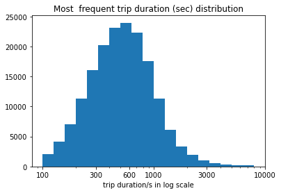

## User type composition

> About 90% of recored users are subscriber.

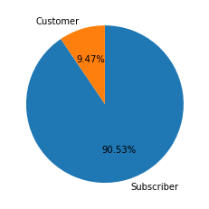

## Bike daily usage counts by customer types

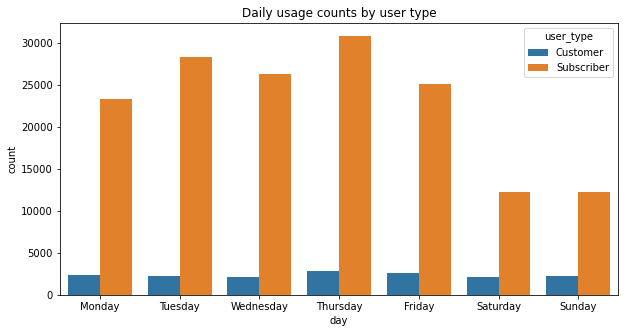

## Bike hourly usage counts by customer types

> Hourly usage counts tendency is same in both customer and subscriber group. In rush hours (8am and 5pm), usage counts are the highest.

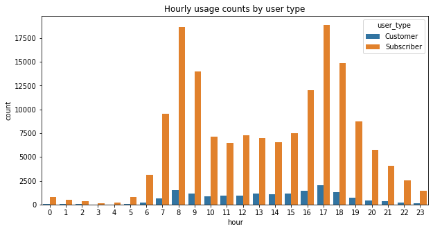

[figure not shown]

## Top 10 most visited start stations by user groups

> Top 10 most visited start stations are not same in "customer" and "subscriber" users.

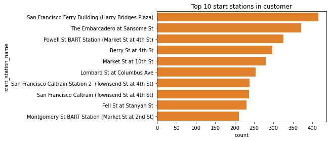

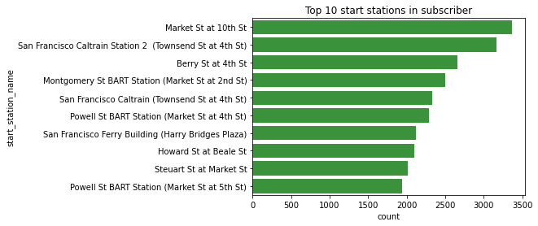

## Average daily usage time by user types

> In average, "customer" users have higher usage time than "subscriber" users. For both two types of users, average usage time is higher in weekends than weekdays.

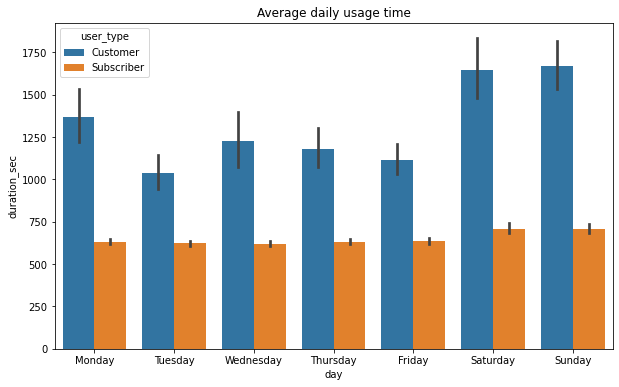

> Surpurisingly, for both two types of users, morning 3 am has the higest average usage time durations.

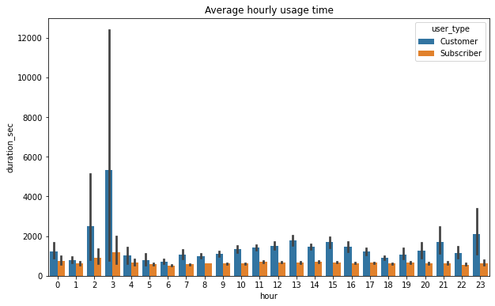